# ЕГЭ 2018 Вариант 10403 EGE 2018 Variant 10403

```python
%%html
<style>
@import url('https://fonts.googleapis.com/css?family=Roboto&effect=3d|scuffed-steel|static|canvas-print|');
a, h1 h2, h3, h4, div.text_cell_render {font-family: 'Roboto'; text-shadow: 4px 4px 4px #aaa;}

h2, h3, div.output_prompt, div.output_area pre {color: slategray;}
h1, h4, div.input_prompt {color: steelblue;}
a, div.output_subarea {color: darkblue;}

span {text-shadow: 4px 4px 4px #aaa;}

body, div.output_stderr pre{background-color: aliceblue;}
div.output_stderr {background-color: slategray;}
</style>
```

```python
import numpy
import pandas
import math

import networkx as nx
import pydot
from networkx.drawing.nx_pydot import graphviz_layout
import prettyplotlib as ppl
from matplotlib_venn import venn2

import matplotlib.pyplot as plt
import matplotlib.patches as pat
from mpl_toolkits.mplot3d import Axes3D
from mpl_toolkits.mplot3d.art3d import Poly3DCollection, Line3DCollection
import matplotlib
%matplotlib inline
```

```python
answer_dictionary = dict()
```

## Часть 1 / Part 1

#### Решение 1 / Solution 1

```python
# a) 213 (основание / base - 8)
2 * 8 ** 2 + 1 * 8 ** 1 + 3 * 8 ** 0
```

```
139
```

```python
# б)
128 + 8 + 4
```

```
140
```

```python
# в) 10001010 (основание / base - 2)
1 * 2 ** 7 + 1 * 2 ** 3 + 1 * 2 ** 1
```

```
138
```

```python
int('213', 8), 128 + 8 + 4, int('10001010',2)
```

```
(139, 140, 138)
```

#### Ответ 1 / Answer 1

$140$

```python
answer_dictionary[1]='140'
```

#### Решение 2 / Solution 2

$( x \land \neg y) \lor ( x \land z) \equiv x \land (\neg y \lor z)$.

$F = TRUE \iff x = TRUE \land (\neg y \lor z) = TRUE \implies x - \#2, y - \#1 \lor \#3$

I.

$y - \#1 \implies z - \#3$

| $y$ | $x$ | $z$ | $x \land (\neg y \lor z)$ |
| --- | --- | --- | --- |
| 0 | 1 | 0 | 1 |
| 0 | 1 | 1 | 1 |
| 1 | 1 | 1 | 1 |

II.

$y - \#3 \implies z - \#1$

| $z$ | $x$ | $y$ | $x \land (\neg y \lor z)$ |
| --- | --- | --- | --- |
| 0 | 1 | 0 | 1 |
| 0 | 1 | 1 | 0 |
| 1 | 1 | 1 | 1 |

#### Ответ 2 / Answer 2

$yxz$

```python
answer_dictionary[2]='yxz'
```

#### Решение 3 / Solution 3

```python
df = pandas.DataFrame(index=['П1=К', 'П2=Г', 'П3=А', 'П4=Д', 'П5=Б', 'П6=Е', 'П7=В'],
                      columns=['П1=К', 'П2=Г', 'П3=А', 'П4=Д', 'П5=Б', 'П6=Е', 'П7=В'])
df = df.fillna(0)
df['П1=К']['П2=Г'],df['П1=К']['П4=Д'],df['П1=К']['П6=Е']=57,20,25
df['П2=Г']['П1=К'],df['П2=Г']['П3=А'],df['П2=Г']['П4=Д'],df['П2=Г']['П5=Б'],df['П2=Г']['П7=В']=57,22,42,8,21
df['П3=А']['П2=Г'],df['П3=А']['П5=Б'],df['П3=А']['П7=В']=22,23,8
df['П4=Д']['П1=К'],df['П4=Д']['П2=Г'],df['П4=Д']['П6=Е'],df['П4=Д']['П7=В']=20,42,7,33
df['П5=Б']['П2=Г'],df['П5=Б']['П3=А']=8,23
df['П6=Е']['П1=К'],df['П6=Е']['П4=Д'],df['П6=Е']['П7=В']=25,7,9
df['П7=В']['П2=Г'],df['П7=В']['П3=А'],df['П7=В']['П4=Д'],df['П7=В']['П6=Е']=21,8,33,9
df
```

|  | П1=К | П2=Г | П3=А | П4=Д | П5=Б | П6=Е | П7=В |
| --- | --- | --- | --- | --- | --- | --- | --- |
| П1=К | 0 | 57 | 0 | 20 | 0 | 25 | 0 |
| П2=Г | 57 | 0 | 22 | 42 | 8 | 0 | 21 |
| П3=А | 0 | 22 | 0 | 0 | 23 | 0 | 8 |
| П4=Д | 20 | 42 | 0 | 0 | 0 | 7 | 33 |
| П5=Б | 0 | 8 | 23 | 0 | 0 | 0 | 0 |
| П6=Е | 25 | 0 | 0 | 7 | 0 | 0 | 9 |
| П7=В | 0 | 21 | 8 | 33 | 0 | 9 | 0 |

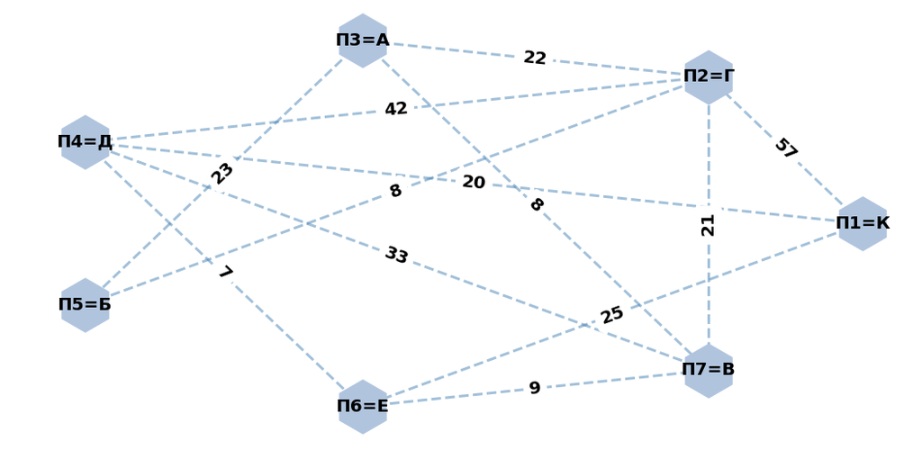

```python
plt.figure(figsize=(18,9))
G=nx.from_pandas_adjacency(df)
pos=nx.shell_layout(G)

nx.draw_networkx_nodes(G,pos,node_size=3800,node_shape="h",
                       node_color='lightsteelblue')
nx.draw_networkx_labels(G,pos,font_size=20,font_weight='bold')
nx.draw_networkx_edges(G,pos,width=3,alpha=0.5,
                       edge_color='steelblue',style='dashed')
edge_labels=\
dict([((u,v,),d['weight']) for u,v,d in G.edges(data=True)])
nx.draw_networkx_edge_labels(G,pos,font_size=20,font_weight='bold',
                             edge_labels=edge_labels)
plt.axis('off');
```

```python
answer_dictionary[3]=str(df['П3=А']['П2=Г'])
```

- Только один узел имеет 2 ребра => Б == П5.
- Только один узел имеет 5 ребер => Г == П2.
- Б - узел с 2 ребрами и Б <-> А (3 ребра) => А == П3.
- В - узел с 4 ребрами и В <-> А => В == П7.
- Д - другой узел с 4 ребрами => Д == П4.
- К - узел с 3 ребрами и К <-> Г => К == П1.
- Е == П6.
- Only one node has 2 edges => Б == П5.
- Only one node has 5 edges => Г == П2.
- Б is a node with 2 edges and Б <-> А (3 edges) => А == П3.
- В - a node with 4 edges and В <-> А => В == П7.
- Д is another node with 4 edges => Д == П4.
- К is a node with 3 edges and К <-> К <-> Г => К == П1.
- Е == П6.

#### Ответ 3 / Answer 3

$22$

#### Решение 4 / Solution 4

|  | Таблица 1 / Table 1 |  |  | Таблица 2 / Table 2 |  |
| --- | --- | --- | --- | --- | --- |
| ID | Фамилия И.О. | Пол | $\; \; \; \; \;$ | ID_Родителя | ID_Ребёнка |
| ID | Surname First name Middle name | Sex | $\; \; \; \; \;$ | ID_Parent | ID_Child |
| 1243 | Бесчастных П.А. | М / M |  | 2230 | 1243 |
| 1248 | Попович А.А. | М / M |  | 2230 | 1251 |
| 1250 | Ан Н.А. | Ж / F |  | 2230 | 3319 |
| 1251 | Ан В.А. | Ж / F |  | 2300 | 6258 |
| 1257 | Фоменко П.И. | М / M |  | 2300 | 1257 |
| 2230 | Фоменко Е.А. | Ж / F |  | 3252 | 6258 |
| 2300 | Фоменко И.А. | М / M |  | 3252 | 1257 |
| 3252 | Фоменко Т.Х. | Ж / F |  | 5215 | 2230 |
| 3293 | Поркуян А.А. | Ж/ F |  | 5215 | 2300 |
| 3319 | Сабо С.А. | Ж / F |  | 6214 | 2230 |
| 5215 | Фоменко А.К. | М / M |  | 6214 | 2300 |
| 6214 | Попович Л.П. | Ж / F |  | 9252 | 1243 |
| 6258 | Фоменко Т.И. | Ж / F |  | 9252 | 1251 |
| 9252 | Бесчастных А.И. | М / M |  | 9252 | 3319 |

|  | $5215_М + 6214_Ж \to 2230_Ж, 2300_М$ |  |
| --- | --- | --- |
| $2230_Ж + 9252_М \to 1243_М, 1251_Ж, 3319_Ж$ |  | $2300_М + 3252_Ж \to 6258_Ж, 1257_М$ |

$1251_Ж = Ан \; В.А.; \; 2300_М = Фоменко \; И.А.$

[output not shown]

$1251_F = Ан \; В.А.; \; 2300_M = Фоменко \; И.А.$

#### Ответ 4 / Answer 4

$2300$

```python
answer_dictionary[4]=str(2300)
```

#### Решение 5 / Solution 5

1) Ни одно кодовое слово не может начинаться с 0 (А - 0).

2) Невозможно использовать 10 и 11: они встречаются в начале кодовых слов (Б - 101, В - 110).

3) Отсутствуют кодовые слова, начинающиеся со 100 и 111. При этом требуется закодировать 3 символа: Г,Д,Е.

Значит 100 может быть использовано в качестве одного из кодовых слов, два других тогда должны быть образованы от 111.

*Например.* Г - 100, Д - 1110, Е - 1111

4) Суммарная длина всех слов равна 1 + 3 + 3 + 3 + 4 + 4 = 18.

1) No code word can begin with 0 (A - 0).

2) It is impossible to use 10 and 11: they occur at the beginning of the code words (B-101, B-110).

3) There are no code words beginning with 100 and 111. It is required to encode 3 symbols: G, D, E.

So 100 can be used as one of the code words, the other two should then be formed from 111.

*For example.* Г - 100, Д - 1110, Е - 1111

4) The total length of all words is 1 + 3 + 3 + 3 + 4 + 4 = 18.

#### Ответ 5 / Answer 5

$18$

```python
answer_dictionary[5]=str(18)
```

#### Решение 6 / Solution 6

17 получается при сложении цифр 9 и 8. Для того, чтобы искомое число стало наибольшим, 9 ставится в первый слева разряд, 8 - во второй.

15 получается при сложении цифр 8 и 7. 8 уже стоит во втором разряде. Значит, 7 ставится в третий слева разряд.

Сумма третьей и четвертой цифры не может превышать 15. Последней цифрой может быть 8.

*Проверка*.

Исходное число: 9878. Суммы: 9 + 8 = 17; 8 + 7 = 15; 7 + 8 = 15. Наибольшие суммы: 17, 15. Результат: 1517.

17 is obtained by adding the digits 9 and 8. In order for the required number to become the largest, 9 is placed in the first left digit, 8 - in the second.

15 is obtained by adding the digits 8 and 7. 8 already stands in the second digit. Hence, 7 is placed in the third left digit.

The sum of the third and fourth digits cannot exceed 15. The last digit can be 8.

*Checking*.

The initial number: 9878. The sums: 9 + 8 = 17; 8 + 7 = 15; 7 + 8 = 15. The largest sums: 17, 15. The result: 1517.

#### Ответ 6 / Answer 6

$9878$

```python
answer_dictionary[6]=str(9878)
```

#### Решение 7 / Solution 7

|  | $A$ | $B$ | $C$ | $D$ | $E$ | $F$ |
| --- | --- | --- | --- | --- | --- | --- |
| $1$ |  |  |  |  |  |  |
| $2$ |  | 0 | 3 | 5 | 7 | 11 |
| $3$ |  | 3 | 9 | 15 | 21 | 33 |
| $4$ |  | 5 | 15 | 25 | 35 | 55 |
| $5$ |  | 7 | 21 | 35 | 49 | 77 |
| $6$ |  | 11 | 33 | 55 | 77 | 121 |

`B1=E$4+$D5`

[Google Sheet](https://drive.google.com/open?id=18YUxq9169Pcrb524MN4P5hLqIBw-xoxGR650dLLxNeM)

`A2=D$4+$D6=80`

#### Ответ 7 / Answer 7

$80$

```python
answer_dictionary[7]=str(80)
```

#### Решение 8 / Solution 8

```python
s = 0
n = 0
while s < 123:
    s = s + 12
    n = n + 3
print(n)
```

```
33
```

#### Ответ 8 / Answer 8

$33$

```python
answer_dictionary[8]=str(n)
```

#### Решение 9 / Solution 9

Показатели, позволяющие определить объем информации.

- Частота дискретизации: 32 кГц, за одну секунду запоминается 32000 значений сигнала.
- Глубина дискретизации (разрешение): 32 бит.
- Время записи: 2 минуты = 120 секунд.
- Запись двухканальная (стерео): объём памяти для хранения данных одного канала умножается на 2 .

Размер полученного файла:

$32000 * 32 * 120 * 2 = 245760000$ бит или $245760000 / 2^3 / 2^{20} ≈ 30$ Мбайт.

Indicators to determine the amount of information.

- Sampling frequency: 32 kHz, 32000 signal values are memorized in one second.
- Depth of sampling (resolution): 32 bit.
- Recording time: 2 minutes = 120 seconds.
- Two-channel recording (stereo): the amount of memory for data storage of one channel is multiplied by 2.

The size of the received file:

$ 32000 * 32 * 120 * 2 = 245760000 $ bit or $ 245760000/2 ^ 3/2 ^ {20} ≈ 30 $ MB.

#### Ответ 9 / Answer 9

$30$

```python
32000 * 32 * 120 * 2 / 2**23
```

```
29.296875
```

```python
answer_dictionary[9]=str(30)
```

#### Решение 10 / Solution 10

Количество кодовых слов с буквой X вида XAAA, XAAB, XABA, ... определяется следующими показателями:

- на первом из четырех мест стоит X,
- остальные 3 позиции занимает одна из четырех букв A,B,C,D.

Получается $4^3 = 64$ варианта.

Количество слов без буквы X вида AAAA, AAAB, AABA, ... определяется следующими показателями:

- каждую из 4 позиций занимает одна из четырех букв A,B,C,D.

Получается $4^4 = 256$ вариантов.

Всего: $64 + 256 = 320$.

The number of code words with the first letter X of the form XAAA, XAAB, XABA, ... is determined by the following indicators:

- the first of four places is X,
- the remaining 3 positions are occupied by one of the four letters A, B, C, D.

It turns out $4^3 = 64$ options.

The number of words without the letter X of the type AAAA, AAAB, AABA, ... is determined by the following indicators:

- each of the 4 positions is occupied by one of the four letters A, B, C, D.

It turns out $4^4 = 256$ options.

Total: $64 + 256 = 320$.

#### Ответ 10 / Answer 10

$320$

```python
answer_dictionary[10]=str(4**3 + 4**4)
```

#### Решение 11 / Solution 11

```python
def F(n):
    if n > 2:
        return F(n - 1) + G(n - 1) + F(n - 2)
    else:
        return n

def G(n):
    if n > 2:
        return G(n - 1) + F(n - 1) + G(n - 2)
    else:
        return n + 1

for i in range(1,6):
    print('n = '+str(i)+'; G(n) = '+str(G(i))+'; F(n) = '+str(F(i)))
```

```
n = 1; G(n) = 2; F(n) = 1
n = 2; G(n) = 3; F(n) = 2
n = 3; G(n) = 7; F(n) = 6
n = 4; G(n) = 16; F(n) = 15
n = 5; G(n) = 38; F(n) = 37
```

F(5) = F(4) + G(4) + F(3)

G(5) = G(4) + F(4) + G(3)

F(4) = F(3) + G(3) + F(2)

G(4) = G(3) + F(3) + G(2)

F(3) = F(2) + G(2) + F(1)

G(3) = G(2) + F(2) + G(1)

F(2) = 2

G(2) = 3

F(1) = 1

G(1) = 2

F(3) = 2 + 3 + 1 = 6

G(3) = 3 + 2 + 2 = 7

F(4) = 6 + 7 + 2 = 15

G(4) = 7 + 6 + 3 = 16

F(5) = 15 + 16 + 6 = 37

G(5) = 16 + 15 + 7 = 38

#### Ответ 11 / Answer 11

$38$

```python
answer_dictionary[11]='38'
```

#### Решение 12 / Solution 12

```python
ip='111.81.208.27'
ip_bin='.'.join([bin(int(x)+256)[3:] for x in ip.split('.')])
print(ip_bin)
```

```
01101111.01010001.11010000.00011011
```

```python
net='111. 81.192.0'
net_bin='.'.join([bin(int(x)+256)[3:] for x in net.split('.')])
print(net_bin)
```

```
01101111.01010001.11000000.00000000
```

```python
mask_third_symbols = []
for x in range(256):
    n1 = numpy.array([int(i) for i in bin(208+256)[3:]])
    n2 = numpy.array([int(i) for i in bin(x+256)[3:]])
    n3 = numpy.array([int(i) for i in bin(192+256)[3:]])
    if min(n1&n2 == n3) == True:
        mask_third_symbols.append(x)
print(mask_third_symbols)
```

```
[192, 193, 194, 195, 196, 197, 198, 199, 200, 201, 202, 203, 204, 205, 206, 207, 224, 225, 226, 227, 228, 229, 230, 231, 232, 233, 234, 235, 236, 237, 238, 239]
```

```python
classes = numpy.arange(4,31,1)
masks = numpy.array(['240.0.0.0','248.0.0.0','252.0.0.0','254.0.0.0','255.0.0.0',
                     '255.128.0.0','255.192.0.0','255.224.0.0','255.240.0.0','255.248.0.0',
                     '255.252.0.0','255.254.0.0','255.255.0.0','255.255.128.0','255.255.192.0',
                     '255.255.224.0','255.255.240.0','255.255.248.0','255.255.252.0','255.255.254.0',
                     '255.255.255.0','255.255.255.128','255.255.255.192','255.255.255.224','255.255.255.240',
                     '255.255.255.248','255.255.255.252'])
mask_dictionary = dict(zip(classes, masks))
mask_dictionary
```

```
{4: '240.0.0.0',
 5: '248.0.0.0',
 6: '252.0.0.0',
 7: '254.0.0.0',
 8: '255.0.0.0',
 9: '255.128.0.0',
 10: '255.192.0.0',
 11: '255.224.0.0',
 12: '255.240.0.0',
 13: '255.248.0.0',
 14: '255.252.0.0',
 15: '255.254.0.0',
 16: '255.255.0.0',
 17: '255.255.128.0',
 18: '255.255.192.0',
 19: '255.255.224.0',
 20: '255.255.240.0',
 21: '255.255.248.0',
 22: '255.255.252.0',
 23: '255.255.254.0',
 24: '255.255.255.0',
 25: '255.255.255.128',
 26: '255.255.255.192',
 27: '255.255.255.224',
 28: '255.255.255.240',
 29: '255.255.255.248',
 30: '255.255.255.252'}
```

```python
symbols = []
for mask in mask_dictionary.values():
    for symbol in mask_third_symbols:
        if (mask[:8] == '255.255.'):
            if mask[8:11] == str(symbol):
                symbols.append(symbol)

answer_dictionary[12]=str(min(symbols))
print('Answer:', min(symbols))
```

```
Answer: 192
```

```python
mask='255.255.192.0'
mask_bin='.'.join([bin(int(x)+256)[3:] for x in mask.split('.')])
print(mask_bin)
```

```
11111111.11111111.11000000.00000000
```

1) В бинарной форме третий байт IP-адрес узла равен `11010000` ($208 = 1 * 2^7 + 1 * 2^6 + 1 * 2^4 $).

2) В бинарной форме третий байт адреса сети равен `11000000` ($192 = 1 * 2^7 + 1 * 2^6$).

3) Значение третьего байта маски будет наименьшим при максимально возможном количестве нулей в бинарной форме этого числа.

4) Третий байт маски `11000000` в десятичной форме равен: $192$.

1) In the binary form, the third byte of the node's IP address is `11010000` ($208 = 1 * 2^7 + 1 * 2^6 + 1 * 2^4$).

2) In the binary form, the third byte of the network address is equal to `11000000` ($192 = 1 * 2^7 + 1 * 2^6$).

3) The value of the third byte of the mask will be the smallest with the maximum possible number of zeros in the binary form of this number.

4) The third byte of the mask `11000000` in decimal form is equal to: $192$.

| Разряды третьего байта | IP-адрес узла | Маска | Адрес сети |
| --- | --- | --- | --- |
| Digits of the Third Byte | IP Address | Mask | Network Address |
| 1 | 1 | 1 | 1 & 1 = 1 |
| 2 | 1 | 1 | 1 & 1 = 1 |
| 3 | 0 | 0 | 0 & 0 (∨ 1) = 0 |
| 4 | 1 | 0 | 1 & 0 = 0 |
| 5 | 0 | 0 | 0 & 0 (∨ 1) = 0 |
| 6 | 0 | 0 | 0 & 0 (∨ 1) = 0 |
| 7 | 0 | 0 | 0 & 0 (∨ 1) = 0 |
| 8 | 0 | 0 | 0 & 0 (∨ 1) = 0 |

#### Ответ 12 / Answer 12

$192$

```python
answer_dictionary[12]='192'
```

#### Решение 13 / Solution 13

1) $3 < log_210 < 4 \implies 4$ (бит) - необходимо для кодирования одной из 10 букв латинского алфавита.

Количество возможных вариантов кодировки ($2^4$) не должно быть меньше количества имеющейся информации (10 символов), округление в данном случае - всегда в большую сторону.

2) $4 ∗ 20 = 80$ (бит) - необходимо для кодирования 20 символов пароля.

3) $80 / 8 = 10$ (байт) - необходимо для кодирования 20 символов пароля.

Количество байт - целое число, и округление (если оно используется) опять должно быть только в большую сторону.

4) $300 / 20 = 15$ (байт) - выделено на одного пользователя для пароля и дополнительной информации.

5) $15 - 10 = 5$ (байт) - выделено на одного пользователя для хранения дополнительных сведений.

1) $3 < log_210 < 4 \implies 4$ (bit) - it is necessary for encoding one of 10 letters of the Latin alphabet.

The number of possible encoding options ($2^4$) should not be less than the amount of information available (10 symbols), rounding in this case - always in the larger side.

2) $4 ∗ 20 = 80$ (bit) - it is necessary to encode 20 characters of the password.

3) $80 / 8 = 10$ (byte) - it is necessary for encoding 20 characters of the password.

The number of bytes is an integer, and rounding (if it is used) again should only be in the larger side.

4) $300 / 20 = 15$ (byte) - it is llocated for one user for the password and additional information.

5) $15 - 10 = 5$ (byte) - it is allocated for one user for storing the additional information.

#### Ответ 13 / Answer 13

$5$

```python
answer_dictionary[13]='5'
```

#### Решение 14 / Solution 14

```python
string = 54*'5'+'7'
string
```

```
'5555555555555555555555555555555555555555555555555555557'
```

```python
def string_function(w):
    while ('722'in w) | ('557'in w):
        if ('722'in w):
            w = w.replace('722', '57')
            print(w)
        else:
            w = w.replace('557', '72')
            print(w)
    return w

answer_dictionary[14]=string_function(string)
```

```
555555555555555555555555555555555555555555555555555572
55555555555555555555555555555555555555555555555555722
5555555555555555555555555555555555555555555555555557
555555555555555555555555555555555555555555555555572
55555555555555555555555555555555555555555555555722
5555555555555555555555555555555555555555555555557
555555555555555555555555555555555555555555555572
55555555555555555555555555555555555555555555722
5555555555555555555555555555555555555555555557
555555555555555555555555555555555555555555572
55555555555555555555555555555555555555555722
5555555555555555555555555555555555555555557
555555555555555555555555555555555555555572
55555555555555555555555555555555555555722
5555555555555555555555555555555555555557
555555555555555555555555555555555555572
55555555555555555555555555555555555722
5555555555555555555555555555555555557
555555555555555555555555555555555572
55555555555555555555555555555555722
5555555555555555555555555555555557
555555555555555555555555555555572
55555555555555555555555555555722
5555555555555555555555555555557
555555555555555555555555555572
55555555555555555555555555722
5555555555555555555555555557
555555555555555555555555572
55555555555555555555555722
5555555555555555555555557
555555555555555555555572
55555555555555555555722
5555555555555555555557
555555555555555555572
55555555555555555722
5555555555555555557
555555555555555572
55555555555555722
5555555555555557
555555555555572
55555555555722
5555555555557
555555555572
55555555722
5555555557
555555572
55555722
5555557
555572
55722
5557
572
```

#### Ответ 14 / Answer 14

$572$

#### Решение 15 / Solution 15

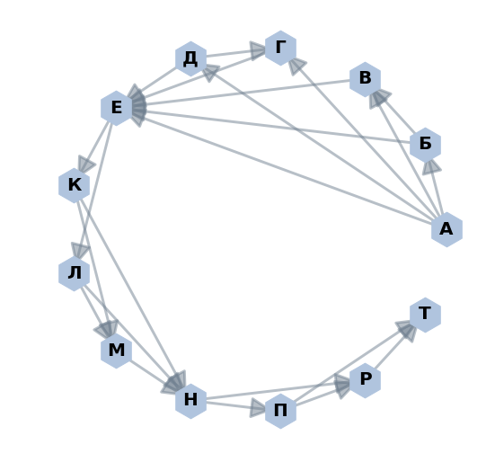

```python
G2 = nx.MultiDiGraph()
plt.figure(figsize=(9,9))

G2.add_edges_from([('А', 'Б'),('А','В'),('А','Г'),('А','Д'),('А','Е')])
G2.add_edges_from([('Б','В'),('Б','Е')])
G2.add_edges_from([('В','Е')])
G2.add_edges_from([('Г','Е')])
G2.add_edges_from([('Д','Г'),('Д','Е')])
G2.add_edges_from([('Е','К'),('Е','Л')])
G2.add_edges_from([('К','М'),('К','Н')])
G2.add_edges_from([('Л','М'),('Л','Н')])
G2.add_edges_from([('М','Н')])
G2.add_edges_from([('Н','П'),('Н','Р')])
G2.add_edges_from([('П','Р'),('П','Т')])
G2.add_edges_from([('Р','Т')])

pos=nx.shell_layout(G2)

nx.draw_networkx_edges(G2, pos, width=3,
                       alpha=0.5, edge_color='slategray',
                       arrowsize=50, arrowstyle='-|>')
nx.draw_networkx_nodes(G2, pos, node_size=1500,
                       node_shape='h', node_color='lightsteelblue')
nx.draw_networkx_labels(G2, pos, font_size=20, font_weight='bold')

plt.axis('off')
plt.show()
```

```python
for path in nx.all_simple_paths(G2, 'А', 'Т'): print (path)
```

```
['А', 'Б', 'В', 'Е', 'К', 'М', 'Н', 'П', 'Р', 'Т']
['А', 'Б', 'В', 'Е', 'К', 'М', 'Н', 'П', 'Т']
['А', 'Б', 'В', 'Е', 'К', 'М', 'Н', 'Р', 'Т']
['А', 'Б', 'В', 'Е', 'К', 'Н', 'П', 'Р', 'Т']
['А', 'Б', 'В', 'Е', 'К', 'Н', 'П', 'Т']
['А', 'Б', 'В', 'Е', 'К', 'Н', 'Р', 'Т']
['А', 'Б', 'В', 'Е', 'Л', 'М', 'Н', 'П', 'Р', 'Т']
['А', 'Б', 'В', 'Е', 'Л', 'М', 'Н', 'П', 'Т']
['А', 'Б', 'В', 'Е', 'Л', 'М', 'Н', 'Р', 'Т']
['А', 'Б', 'В', 'Е', 'Л', 'Н', 'П', 'Р', 'Т']
['А', 'Б', 'В', 'Е', 'Л', 'Н', 'П', 'Т']
['А', 'Б', 'В', 'Е', 'Л', 'Н', 'Р', 'Т']
['А', 'Б', 'Е', 'К', 'М', 'Н', 'П', 'Р', 'Т']
['А', 'Б', 'Е', 'К', 'М', 'Н', 'П', 'Т']
['А', 'Б', 'Е', 'К', 'М', 'Н', 'Р', 'Т']
['А', 'Б', 'Е', 'К', 'Н', 'П', 'Р', 'Т']
['А', 'Б', 'Е', 'К', 'Н', 'П', 'Т']
['А', 'Б', 'Е', 'К', 'Н', 'Р', 'Т']
['А', 'Б', 'Е', 'Л', 'М', 'Н', 'П', 'Р', 'Т']
['А', 'Б', 'Е', 'Л', 'М', 'Н', 'П', 'Т']
['А', 'Б', 'Е', 'Л', 'М', 'Н', 'Р', 'Т']
['А', 'Б', 'Е', 'Л', 'Н', 'П', 'Р', 'Т']
['А', 'Б', 'Е', 'Л', 'Н', 'П', 'Т']
['А', 'Б', 'Е', 'Л', 'Н', 'Р', 'Т']
['А', 'В', 'Е', 'К', 'М', 'Н', 'П', 'Р', 'Т']
['А', 'В', 'Е', 'К', 'М', 'Н', 'П', 'Т']
['А', 'В', 'Е', 'К', 'М', 'Н', 'Р', 'Т']
['А', 'В', 'Е', 'К', 'Н', 'П', 'Р', 'Т']
['А', 'В', 'Е', 'К', 'Н', 'П', 'Т']
['А', 'В', 'Е', 'К', 'Н', 'Р', 'Т']
['А', 'В', 'Е', 'Л', 'М', 'Н', 'П', 'Р', 'Т']
['А', 'В', 'Е', 'Л', 'М', 'Н', 'П', 'Т']
['А', 'В', 'Е', 'Л', 'М', 'Н', 'Р', 'Т']
['А', 'В', 'Е', 'Л', 'Н', 'П', 'Р', 'Т']
['А', 'В', 'Е', 'Л', 'Н', 'П', 'Т']
['А', 'В', 'Е', 'Л', 'Н', 'Р', 'Т']
['А', 'Г', 'Е', 'К', 'М', 'Н', 'П', 'Р', 'Т']
['А', 'Г', 'Е', 'К', 'М', 'Н', 'П', 'Т']
['А', 'Г', 'Е', 'К', 'М', 'Н', 'Р', 'Т']
['А', 'Г', 'Е', 'К', 'Н', 'П', 'Р', 'Т']
```

[output cut: 29 more lines]

```
['А', 'Д', 'Е', 'Л', 'Н', 'П', 'Р', 'Т']
['А', 'Д', 'Е', 'Л', 'Н', 'П', 'Т']
['А', 'Д', 'Е', 'Л', 'Н', 'Р', 'Т']
['А', 'Е', 'К', 'М', 'Н', 'П', 'Р', 'Т']
['А', 'Е', 'К', 'М', 'Н', 'П', 'Т']
['А', 'Е', 'К', 'М', 'Н', 'Р', 'Т']
['А', 'Е', 'К', 'Н', 'П', 'Р', 'Т']
['А', 'Е', 'К', 'Н', 'П', 'Т']
['А', 'Е', 'К', 'Н', 'Р', 'Т']
['А', 'Е', 'Л', 'М', 'Н', 'П', 'Р', 'Т']
['А', 'Е', 'Л', 'М', 'Н', 'П', 'Т']
['А', 'Е', 'Л', 'М', 'Н', 'Р', 'Т']
['А', 'Е', 'Л', 'Н', 'П', 'Р', 'Т']
['А', 'Е', 'Л', 'Н', 'П', 'Т']
['А', 'Е', 'Л', 'Н', 'Р', 'Т']
```

```python
answer_dictionary[15]=str(len(list(nx.all_simple_paths(G2, 'А', 'Т'))))
```

$А \to Е$ - 7 дорог / ways, $Е \to Н$ - 4 дороги / ways, $Н \to Т$ - 3 дороги / ways.

$7 * 4 * 3 = 84$

#### Ответ 15 / Answer 15

$84$

#### Решение 16 / Solution 16

$34_5 + x = 34_7$

$34_5 = 3 * 5 + 4 = 19; \; 34_7 = 3 * 7 + 4 = 25 \implies 19_{10} + x = 25_{10} \iff x = 6_{10} = 6_{8}$

#### Ответ 16 / Answer 16

$6$

```python
answer_dictionary[16]=str(6)
```

#### Решение 17 / Solution 17

$Германия \; \& \; (Франция \; \mid \; Австрия) = Германия \; \& \; Франция \mid Германия \; \& \; Австрия$

$Германия \; \& \; (Франция \; \mid \; Австрия) = Франция \; \& \; Германия + Германия \; \& \; Австрия - Франция \; \& \; Германия \; \& \; Австрия$

$Германия \; \& \; Австрия = Германия \; \& \; (Франция \; \mid \; Австрия) + Франция \; \& \; Германия \; \& \; Австрия - Франция \; \& \; Германия$

$Германия \; \& \; Австрия = 467 + 104 - 274 = 297$

#### Ответ 17 / Answer 17

$297$

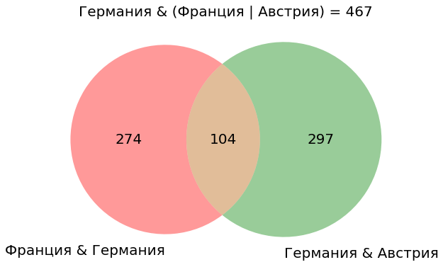

```python
Germany_and_France = 274
Germany_and_France_or_Austria = 467
Germany_and_France_and_Austria = 104

Germany_and_Austria = Germany_and_France_or_Austria + Germany_and_France_and_Austria - Germany_and_France

search_sets =[Germany_and_France, Germany_and_Austria, Germany_and_France_and_Austria]

plt.figure(figsize=(9,9))
v=venn2(subsets=search_sets, set_labels=('Франция & Германия', 'Германия & Австрия'))

for text in v.set_labels:
    text.set_fontsize(20)
for text in v.subset_labels:
    text.set_fontsize(20)

plt.title('Германия & (Франция | Австрия) = 467',fontsize=20)

plt.show()
```

```python
answer_dictionary[17]=str(467 + 104 - 274)
```

#### Решение 18 / Solution 18

```python
bin(28), bin(45), bin(17)
```

```
('0b11100', '0b101101', '0b10001')
```

I способ / I method

Преобразование формулы с использованием законов логики:

Transformations of formulas using the laws of logic:

$((x \& 28 \neq 0) \lor (x \& 45 \neq 0)) \to (x \& 17 = 0 \to x \& A \neq 0) \iff$

$((x \& 28 \neq 0) \lor (x \& 45 \neq 0)) \to ((x \& 17 \neq 0) \lor (x \& A \neq 0)) \iff$

$\neg ((x \& 28 \neq 0) \lor (x \& 45 \neq 0)) \lor ((x \& 17 \neq 0) \lor (x \& A \neq 0)) \iff$

$((x \& 28 = 0) \land (x \& 45 = 0)) \lor ((x \& 17 \neq 0) \lor (x \& A \neq 0))$

Поиск условий для того, чтобы при любых бинарных комбинациях формула принимала значение 1:

The search for conditions so that for any binary combinations the formula takes the value 1:

$((x \& 11100_2 = 0) \land (x \& 101101_2 = 0)) \lor ((x \& 10001_2 \neq 0) \lor (x \& A \neq 0))$

$( *?000??_2 \land *0?00?0_2 ) \lor ( *?1????_2 \lor *1_2 ) \lor (x \& A \neq 0)$

$( *0000?0_2 ) \lor ( *?1????_2) \lor (*?????1_2 ) \lor (x \& A \neq 0)$

$( *0000?0_2 ) \lor ( *?1????_2) \lor (*?????1_2) \lor (*1011?0_2 )$

$ A = *101100_2 \lor *101110_2 \implies A_{min} = 101100_2 = 44_{10} $

II способ / II method

Преобразование формулы с использованием законов логики:

Transformations of formulas using the laws of logic:

$((x \& 28 \neq 0) \lor (x \& 45 \neq 0)) \to (x \& 17 = 0 \to x \& A \neq 0) \iff$

$((x \& 28 \neq 0) \lor (x \& 45 \neq 0)) \to ((x \& 17 \neq 0) \lor (x \& A \neq 0)) \iff$

$\neg ((x \& 28 \neq 0) \lor (x \& 45 \neq 0)) \lor ((x \& 17 \neq 0) \lor (x \& A \neq 0)) \iff$

$\neg ((x \& 28 \neq 0) \lor (x \& 45 \neq 0)) \lor (\neg (x \& 17 = 0) \lor \neg (x \& A = 0)) \iff$

$(\neg (x \& 28 \neq 0) \land \neg (x \& 45 \neq 0)) \lor (\neg (x \& 17 = 0) \lor \neg (x \& A = 0)) \iff$

$((x \& 28 = 0) \land (x \& 45 = 0)) \lor (\neg (x \& 17 = 0) \lor \neg (x \& A = 0)) \iff$

$((x \& 28 = 0) \land (x \& 45 = 0)) \lor \neg ((x \& 17 = 0) \land (x \& A = 0)) \iff$

$((x \& 17 = 0) \land (x \& A = 0)) \to ((x \& 28 = 0) \land (x \& 45 = 0))$

Поиск бинарных комбинаций, при которых слева и справа в импликации единицы стоят в одинаковых разрядах двоичной записи.

Searching for binary combinations in which units on the left and on the right in the implication stand in the same bits of binary notation.

$((x \& 10001_2 = 0) \land (x \& A = 0)) \to ((x \& 11100_2 = 0) \land (x \& 101101_2 = 0))$

$((x \& 10001_2 = 0) \land (x \& A = 0)) \to (x \& 111101_2 = 0)$

$((x \& 10001_2 = 0) \land (x \& 1?110?_2= 0)) \to (x \& 111101_2 = 0)$

$ \min 1?110?_2 = 101100_2 \implies A_{min} = 101100_2 = 44_{10}$

#### Ответ 18 / Answer 18

$44$

```python
answer_dictionary[18]='44'
```

#### Решение 19 / Solution 19

```python
A = [4, 4, 6, 8, 5, 8, 2, 10, 9, 14]
c = 0
for i in range(1,10):
    if A[i] > A[0]:
        c = c + 1
        t = A[i]
        A[i] = A[0]
        A[0] = t
c
```

```
4
```

Программа последовательно находит элемент массива, больший нулевого, и меняет этот элемент с нулевым местами.

Переменная $c$ - количество таких перестановок.

The program sequentially finds an array element larger than the element with the zero index, and puts this element to the beginning.

The variable $c$ is the number of these permutations.

```python
# расширенная версия программы, показывающая, сколько раз менялся первый элемент:
A = [4, 4, 6, 8, 5, 8, 2, 10, 9, 14]
c = 0
for i in range(1,10):
    if A[i] > A[0]:
        c = c + 1
        t = A[i]
        A[i] = A[0]
        A[0] = t
    print(c,A[0])
answer_dictionary[19]=str(c)
```

```
0 4
1 6
2 8
2 8
2 8
2 8
3 10
3 10
4 14
```

#### Ответ 19 / Answer 19

$4$

#### Решение 20 / Solution 20

```python
x = int(input())
a=0; b=0
while x > 0:
    a=a+1
    if x%2==0:
        b+=x%10
    x=x//10
print(a)
print(b)
```

```
982
3
10
```

Программа считает количество цифр в числе ($a$) и сумму всех четных цифр этого числа ($b$).

$a = 3$ для трехзначного числа, $b=10$ для чисел 128, 146, 164, 182, 208, 218, ..., у которых сумма четных цифр будет равна 10.

Макимально возможным среди них будет 982.

The program considers the number of digits in the number ($a$) and the sum of all the even digits of this number ($b$).

$a = 3$ for a three-digit number, $b = 10$ for numbers 128, 146, 164, 182, 208, 218, ..., for which the sum of even numbers will be 10.

The maximum possible number among them will be 982.

#### Ответ 20 / Answer 20

$982$

```python
# расширенная версия программы
T = []
for x in range(100,999):
    a=0; b=0
    t = x
    while x > 0:
        a=a+1
        if x%2==0:
            b+=x%10
        x=x//10
    if a == 3 and b == 10:
        T.append(t)
print(T)
```

```
[128, 146, 164, 182, 208, 218, 226, 238, 244, 258, 262, 278, 280, 281, 283, 285, 287, 289, 298, 328, 346, 364, 382, 406, 416, 424, 436, 442, 456, 460, 461, 463, 465, 467, 469, 476, 496, 528, 546, 564, 582, 604, 614, 622, 634, 640, 641, 643, 645, 647, 649, 654, 674, 694, 728, 746, 764, 782, 802, 812,…
```

```python
answer_dictionary[20]=str(max(T))
```

#### Решение 21 / Solution 21

```python
def F(x):
    return 2*(x*x-1)*(x*x-1)+7
a=-10; b=20
M=a; R=F(a)
for t in range(a,b+1):
    if F(t)<R:
        M=t; R=F(t)
print(M+10)
```

```
9
```

Программа находит целое число $x$ на интервале $[-10,20]$, для которого значение функции $F(x)$ будет минимальным.

Если одинаковых минимальных значений функции несколько, то программа находит точку, в которой этот минимум достигается первый раз.

Окончательный результат - сумма найденного таким образом целого числа и 10.

The program finds an integer $x$ on the interval $[- 10,20]$, for which the value of the function $F (x)$ is minimal.

If there are several identical minimum values of the function, then the program finds the point at which this minimum is reached for the first time.

The final result is the sum of the integer found in this way and 10.

$F(x) = 2 * (x * x - 1) * (x * x - 1) + 7 = 2 * (x^2 - 1)^2 + 7 = 2 * x^4 - 4 * x^2 + 9$

$F'(x) = 8 * x^3 - 8 * x; \; F''(x) = 24 * x^2 - 8$

$F'(x) = 0 \iff x = -1 \lor x = 0 \lor x = 1$

$F''(-1) = 16 > 0; \; F''(0) = -8 < 0; \; F''(1) = 16 > 0$

$M = -1 \implies M + 10 = 9$

#### Ответ 21 / Answer 21

$9$

```
9
```

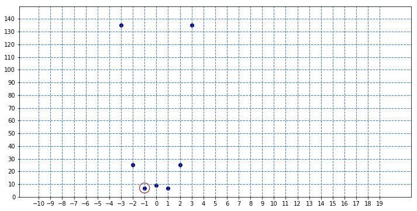

```python
# расширенная версия программы
plt.figure(figsize=(12,6))
plt.ylim(0,150)
plt.xticks(numpy.arange(-10, 20, step=1))
plt.yticks(numpy.arange(0, 150, step=10))
plt.grid(c='steelblue', ls='--', lw=1)
def F(x):
    return 2*(x*x-1)*(x*x-1)+7
a=-10; b=20
M=a; R=F(a)
for t in range(a,b+1):
    if F(t)<R:
        M=t; R=F(t)
    plt.scatter(t,F(t),c='darkblue')
plt.scatter(M,R,s=300,facecolor='none',color='darkred')
print(M+10)
```

```python
answer_dictionary[21]=str(M+10)
```

#### Решение 22 / Solution 22

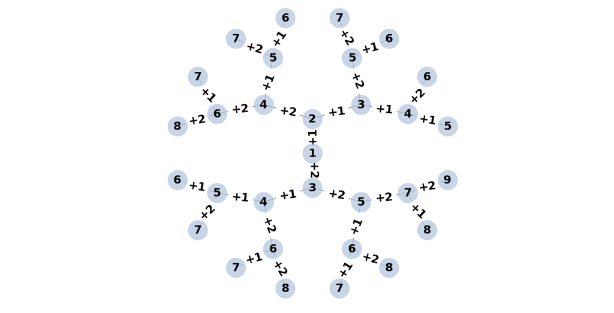

```python
G3 = nx.balanced_tree(2, 4)
pos = graphviz_layout(G3, prog='twopi', args='')

plt.figure(figsize=(18, 9))
node_labels={0:1, 1:2, 2:3, 3:3, 4:4, 5:4, 6:5, 7:4,
             8:5, 9:5, 10:6, 11:5, 12:6, 13:6, 14:7,
             15:5, 16:6, 17:6, 18:7, 19:6, 20:7, 21:7, 22:8,
             23:6, 24:7, 25:7, 26:8, 27:7, 28:8, 29:8, 30:9}
edge_labels={(0,1):'+1', (0,2):'+2', (1,3):'+1', (1,4):'+2', (2,5):'+1', (2,6):'+2',
             (3,7):'+1', (3,8):'+2', (4,9):'+1', (4,10):'+2', (5,11):'+1', (5,12):'+2',
             (6,13):'+1', (6,14):'+2', (7,15):'+1', (7,16):'+2', (8,17):'+1', (8,18):'+2',
             (9,19):'+1', (9,20):'+2', (10,21):'+1', (10,22):'+2', (11,23):'+1', (11,24):'+2',
             (12,25):'+1', (12,26):'+2', (13,27):'+1', (13,28):'+2', (14,29):'+1', (14,30):'+2'}

nx.draw(G3, pos, node_size=1800, alpha=0.7, node_color="lightsteelblue")
nx.draw_networkx_labels(G3, pos, node_labels, font_size=25, font_weight='bold')
nx.draw_networkx_edge_labels(G3, pos, edge_labels, font_size=25, font_weight='bold')
plt.axis('equal')
plt.show()
```

$1 \to 7$ - 13 траекторий / ways

| Последовательность чисел | Программа |
| --- | --- |
| Sequence of Numbers | Program |
| 1,2,3,4,5,6,7 | `111111` |
| 1,2,3,4,5,7 | `11112` |
| 1,2,3,4,6,7 | `11121` |
| 1,2,3,5,6,7 | `11211` |
| 1,2,4,5,6,7 | `12111` |
| 1,3,4,5,6,7 | `21111` |
| 1,2,3,5,7 | `1122` |
| 1,2,4,5,7 | `1212` |
| 1,2,4,6,7 | `1221` |
| 1,3,4,5,7 | `2112` |
| 1,3,4,6,7 | `2121` |
| 1,3,5,6,7 | `2211` |
| 1,3,5,7 | `222` |

$7 \to 13 \; (без \; 9! \; / \; without \; 9!)$ - 3 траектории / ways

| Последовательность чисел | Программа |
| --- | --- |
| Sequence of Numbers | Program |
| 7,8,10,11,12,13 | `12111` |
| 7,8,10,11,13 | `1212` |
| 7,8,10,12,13 | `1221` |

13 * 3 = 39

#### Ответ 22 / Answer 22

$39$

```python
x = [1]
for i in range(6):
    n=int(len(x)-2**i)
    y=[el+1 for el in x[n:]]
    z=[el+2 for el in x[n:]]
    x=x+y+z

print(x, '\n\n'+str(len(x))+'; '+str(x.count(7)))
```

```
[1, 2, 3, 3, 4, 4, 5, 4, 5, 5, 6, 5, 6, 6, 7, 5, 6, 6, 7, 6, 7, 7, 8, 6, 7, 7, 8, 7, 8, 8, 9, 6, 7, 7, 8, 7, 8, 8, 9, 7, 8, 8, 9, 8, 9, 9, 10, 7, 8, 8, 9, 8, 9, 9, 10, 8, 9, 9, 10, 9, 10, 10, 11, 7, 8, 8, 9, 8, 9, 9, 10, 8, 9, 9, 10, 9, 10, 10, 11, 8, 9, 9, 10, 9, 10, 10, 11, 9, 10, 10, 11, 10, 11, …

127; 13
```

```python
answer_dictionary[22]=str(13*3)
```

#### Решение 23 / Solution 23

$(\neg(x_1 \equiv y_1) \to \neg(x_2 \equiv y_2)) \land (x_1 \to x_2) \land (y_1 \to y_2) = 1; \; (*)$

$(\neg(x_2 \equiv y_2) \to \neg(x_3 \equiv y_3)) \land (x_2 \to x_3) \land (y_2 \to y_3) = 1; \; (**)$

$...$

$(\neg(x_8 \equiv y_8) \to \neg(x_9 \equiv y_9)) \land (x_8 \to x_9) \land (y_8 \to y_9) = 1.$

1)

$(*) = 0 \iff (x_1 \equiv y_1 = 0 \land x_2 \equiv y_2 = 1) \lor x_1 \to x_2 = 0 \lor y_1 \to y_2 = 0$

| $x_1$ | $x_2$ | $y_1$ | $y_2$ |
| --- | --- | --- | --- |
| 1 | 0 | 0 | 0 |
| 1 | 0 | 0 | 1 |
| 1 | 0 | 1 | 1 |
| 1 | 0 | 1 | 0 |
| 0 | 0 | 1 | 0 |
| 0 | 1 | 1 | 0 |
| 1 | 1 | 1 | 0 |
| 1 | 1 | 0 | 1 |
| 0 | 1 | 1 | 1 |

$(**) = 0 \iff (x_2 \equiv y_2 = 0 \land x_3 \equiv y_3 = 1) \lor x_2 \to x_3 = 0 \lor y_2 \to y_3 = 0$

| $x_2$ | $x_3$ | $y_2$ | $y_3$ |
| --- | --- | --- | --- |
| 1 | 0 | 0 | 0 |
| 1 | 0 | 0 | 1 |
| 1 | 0 | 1 | 1 |
| 1 | 0 | 1 | 0 |
| 0 | 0 | 1 | 0 |
| 0 | 1 | 1 | 0 |
| 1 | 1 | 1 | 0 |
| 1 | 1 | 0 | 1 |
| 0 | 1 | 1 | 1 |

2)

$(*) = 1 \iff \begin {cases} (x_1,y_1) = (0,0) \land (x_2,y_2) = (0,0),(0,1),(1,0),(1,1) \\ (x_1,y_1) = (0,1) \land (x_2,y_2) = (0,1) \\ (x_1,y_1) = (1,0) \land (x_2,y_2) = (1,0) \\ (x_1,y_1) = (1,1) \land (x_2,y_2) = (1,1) \end {cases}$

$(**) = 1 \iff \begin {cases} (x_2,y_2) = (0,0) \land (x_3,y_3) = (0,0),(0,1),(1,0),(1,1) \\ (x_2,y_2) = (0,1) \land (x_3,y_3) = (0,1) \\ (x_2,y_2) = (1,0) \land (x_3,y_3) = (1,0) \\ (x_2,y_2) = (1,1) \land (x_3,y_3) = (1,1) \end {cases}$

$(*) = 1 \land (**) = 1 \iff \begin {cases} (x_1,y_1) = (0,0) \land (x_2,y_2) = (0,0) \land (x_3,y_3) = (0,0),(0,1),(1,0),(1,1) \\ (x_1,y_1) = (0,0) \land (x_2,y_2) = (0,1) \land (x_3,y_3) = (0,1) \\ (x_1,y_1) = (0,0) \land (x_2,y_2) = (1,0) \land (x_3,y_3) = (1,0) \\ (x_1,y_1) = (0,0) \land (x_2,y_2) = (1,1) \land (x_3,y_3) = (1,1) \\ (x_1,y_1) = (0,1) \land (x_2,y_2) = (0,1) \land (x_3,y_3) = (0,1) \\ (x_1,y_1) = (1,0) \land (x_2,y_2) = (1,0) \land (x_3,y_3) = (1,0) \\ (x_1,y_1) = (1,1) \land (x_2,y_2) = (1,1) \land (x_3,y_3) = (1,1) \end {cases}$

3)

Первое равенство системы логических уравнений выполняется для 7 наборов $x_1,y_1,x_2,y_2$.

Первое и второе равенства системы логических уравнений выполняются для 7 + 3 * 1 = 10 наборов $x_1,y_1,x_2,y_2,x_3,y_3$.

...

Все равенства системы логических уравнений выполняются для 7 + 3 * 7 = 28 наборов $x_1,y_1,x_2,y_2,x_3,y_3,x_4,y_4,x_5,y_5,x_6,y_6,x_7,y_7,x_8,y_8,x_9,y_9$.

The first equation in the system of logical equations is satisfied for 7 sets $ x_1, y_1, x_2, y_2 $.

The first and second equations in the system of logical equations are satisfied for 7 + 3 * 1 = 10 sets $ x_1, y_1, x_2, y_2, x_3, y_3 $.

...

All equations in the system of logical equations are satisfied for 7 + 3 * 7 = 28 sets $x_1,y_1,x_2,y_2,x_3,y_3,x_4,y_4,x_5,y_5,x_6,y_6,x_7,y_7,x_8,y_8,x_9,y_9$.

#### Ответ 23 / Answer 23

$28$

```python
answer_dictionary[23]=str(7+7*3)
```

## Часть 2 / Part 2

#### Решение 24 / Solution 24

```python
# 1.
n = int(input())
k = 2
while n % 2 == 0:
    n = n // 2
    k = k + 1
print (k)
```

```
2016
7
```

```python
# 2.1
n = int(input())
k = 2
while n % 2 == 0:
    n = n // 2
    k = k + 1
print (k)
```

```
4
4
```

```python
# 2.2
n = int(input())
k = 2
while n % 2 == 0:
    n = n // 2
    k = k + 1
print (k)
```

```
12
4
```

```python
# 3.
n = int(input())
k = 1
while n % 2 == 0:
    n = n // 2
    k = k * 2
print (k)
```

```
2016
32
```

#### Ответ 24 / Answer 24

$1. \; 7; \\ 2. \; input = 4 \to output = 4, input = 12 \to output = 4; \\ 3. \; k = 2 \to k = 1, k = k + 1 \to k = k * 2$

```python
answer_dictionary[24]='1.7; 2.input=4→output=4, input=12→output=4; 3.k=2→k=1, k=k+1→k=k∗2'
```

#### Решение 25 / Solution 25

```python
# для замены процесса ввода 2016 чисел с клавиатуры
# для тестирования программы сгенерирован массив целых чисел случайным образом
N = 2016
a = numpy.random.randint(1000, size=N)
a.shape
```

```
(2016,)
```

```python
# версия программы без ввода элементов с клавиатуры
N = 2016
a = numpy.random.randint(1000, size=N)
m,s,p = 0,0,0
for i in range(N):
    if a[i] > m:
        m = a[i]
    if a[i] % 2 == 0:
        s = s + a[i]
    else:
        p = p + a[i]
if m% 2 == 0:
    print(m, s)
else:
    print(m, p)
```

```
999 482111
```

```python
# версия программы с вводом элементов с клавиатуры с 10 элементами массива
N = 10
a = []
m,s,p = 0,0,0
for i in range(N):
    a.append(int(input()))
    if a[i] > m:
        m = a[i]
    if a[i] % 2 == 0:
        s = s + a[i]
    else:
        p = p + a[i]
if m % 2 == 0:
    print('\n' + str(s))
else:
    print('\n' + str(p))
```

```
11
12
13
14
15
16
17
18
19
20

80
```

#### Ответ 25 / Answer 25

```bash
N = 2016
a = []
m,s,p = 0,0,0
for i in range(N):
    a.append(int(input()))
    if a[i] > m:
        m = a[i]
    if a[i] % 2 == 0:
        s = s + a[i]
    else:
        p = p + a[i]
if m % 2 == 0:
    print('\n' + str(s))
else:
    print('\n' + str(p))
```

```python
answer_dictionary[25]=\
'''
N = 2016
a = []
m,s,p = 0,0,0
for i in range(N):
    a.append(int(input()))
    if a[i] > m:
        m = a[i]
    if a[i] % 2 == 0:
        s = s + a[i]
    else:
        p = p + a[i]
if m % 2 == 0:
    print('\n' + str(s))
else:
    print('\n' + str(p))
'''
```

#### Решение 26 / Solution 26

$Задание \; 1$ / $Task \; 1$

- $а.$ `27≤S≤53`.

При `27≤S≤53`, $S \in \{27,...,53\}$ Петя выигрывает одним ходом - удваивая количество камней: `54≤2*S≤106`, $2∗S \in \{54,...,106\}$.

При `1≤S≤26`, $S \in \{1,...,26\}$ невозможно выиграть одним ходом: `2≤S+1≤27` $S+1 \in \{2,...,27\}$; `4≤S+3≤29`, $S+3 \in \{4,...,29\}$; `2≤2*S≤52`, $2*S \in \{2,...,52\}$.

`27≤S≤53`, $S \in \{27,...,53\}$. Petya wins by one step - doubling the number of stones: `54≤2*S≤106`, $2∗S \in \{54,...,106\}$.

`1≤S≤26`, $S \in \{1,...,26\}$. It is impossible to win by one step: `2≤S+1≤27` $S+1 \in \{2,...,27\}$; `4≤S+3≤29`, $S+3 \in \{4,...,29\}$; `2≤2*S≤52`, $2*S \in \{2,...,52\}$.

- $б.$ `S=26`.

При любом следующем шаге `26 -> 27 (P +1)`, `26 -> 29 (P +3)`, `26 -> 52 (P *2)` Петя выиграть не сможет,

а Ваня гарантированно победит, удвоив результат на следующем этапе: `27 -> 54 (V *2)`, `29 -> 58 (V *2)`, `52 -> 104 (V *2)`.

At any next step, `26 -> 27 (P +1)`, `26 -> 29 (P +3)`, `26 -> 52 (P *2)` Petya will not be able to win,

and Vanya will win in any cases by doubling the result in the next stage: `27 -> 54 (V *2)`, `29 -> 58 (V *2)`, `52 -> 104 (V *2)`.

$Задание \; 2$. / $Task \; 2$.`S=13, S=23, S=25`.

Петя должен выбрать тогда ход `13 -> 26 (P *2)`, `23 -> 26 (P +3)`, `25 -> 26 (P +1)`.

При любом следующем шаге `26 -> 27 (V +1)`, `26 -> 29 (V +3)`, `26 -> 52 (V *2)` Ваня выиграть не сможет,

а Петя победит, удвоив результат на следующем этапе: `27 -> 54 (P *2)`, `29 -> 58 (P *2)`, `52 -> 104 (P *2)`.

Petya should choose the step `13 -> 26 (P *2)`, `23 -> 26 (P +3)`, `25 -> 26 (P +1)`.

At any next step, `26 -> 27 (V +1)`, `26 -> 29 (V +3)`, `26 -> 52 (V *2)` Vanya cannot win,

but Petya wins by doubling the result in the next stage: `27 -> 54 (P *2)`, `29 -> 58 (P *2)`, `52 -> 104 (P *2)`.

$Задание \; 3$. / $Task \; 3$. `S=22,S=24`.

**Выигрышная стратегия Вани**:

Если первый ход Пети `22 -> 23 (P +1)`, `22 -> 25 (P +3)`, `24 -> 25 (P +1)`,

то Ваня должен выбрать ход `23 -> 26 (V +3)`, `25 -> 26 (V +1)` соответственно.

В этом случае при любом следующем шаге `26 -> 27 (P +1)`, `26 -> 29 (P +3)`, `26 -> 52 (P *2)` Петя выиграть не сможет,

а Ваня гарантированно победит, удвоив результат на следующем этапе: `27 -> 54 (V *2)`, `29 -> 58 (V *2)`, `52 -> 104 (V *2)`.

Если первый ход Пети `22 -> 44 (P *2)`, `24 -> 27 (P +3)`, `24 -> 48 (P *2)`,

то Ваня выигрывает первым своим ходом, удвоив количество камней: `44 -> 88 (V *2)`, `27 -> 54 (V *2)`, `48 -> 96 (V *2)`.

Ваня не сможет гарантированно победить первым же ходом при таких стартовых позициях.

**Vanya's winning strategy**:

If the first move of Petya is one of these: `22 -> 23 (P +1)`, `22 -> 25 (P +3)`, `24 -> 25 (P +1)`,

then Vanya should choose the course `23 -> 26 (V +3)`, `25 -> 26 (V +1)` respectively.

In this case, at any next step, `26 -> 27 (P +1)`, `26 -> 29 (P +3)`, `26 -> 52 (P *2)` Petya will not be able to win,

and Vanya will win by doubling the result in the next stage: `27 -> 54 (V *2)`, `29 -> 58 (V *2)`, `52 -> 104 (V *2)`.

If the first move of Petya is one of these: `22 -> 44 (P *2)`, `24 -> 27 (P +3)`, `24 -> 48 (P *2)`,

then Vanya wins by his first move, doubling the number of stones: `44 -> 88 (V *2)`, `27 -> 54 (V *2)`, `48 -> 96 (V *2)`.

It is not possible for Vanya to win by the first move with a guarantee from these start positions.

```python
answer1 = \
'''
Задание 1.
a. 27≤S≤53 → 54≤2*S≤106.
b. S=26. 26->27(P+1),26->29(P+3),26->52(P*2); 27->54(V*2),29->58(V*2),52->104(V*2).
'''
answer2 = \
'''
Задание 2.
S=13, S=23, S=25.
13->26(P*2),23->26(P+3),25->26(P+1)
26->27(V+1),26->29(V+3),26->52(V*2)
27->54(P*2),29->58(P*2),52->104(P*2)
'''
answer3 = \
'''
Задание 3.
S=22, S=24.
22->23(P+1),22->25(P+3),22->44(P*2) ∨ 24->25(P+1),24->27(P+3),24->48(P*2)
23->26(V+3),25->26(V+1),44->88(V*2),27->54(V*2),48->96(V*2)
26->27(P+1),26->29(P+3),26->52(P*2)
27->54(V*2),29->58(V*2),52->104(V*2)
'''
```

```python
answer_dictionary[26]=[answer1, answer2, answer3]
```

#### Ответ 26 / Answer 26

Задание 1 / Task 1

$a. 27≤S≤53 → 54≤2*S≤106.$

$b. S=26. \; 26\to27(P+1),26\to29(P+3),26\to52(P*2); \; 27\to54(V*2),29\to58(V*2),52\to104(V*2).$

Задание 2 / Task 2

$S=13, S=23, S=25.$

$13\to26(P*2),23\to26(P+3),25\to26(P+1)$

$26\to27(V+1),26\to29(V+3),26\to52(V*2)$

$27\to54(P*2),29\to58(P*2),52\to104(P*2)$

Задание 3 / Task 3

$S=22, S=24.$

$22\to23(P+1),22\to25(P+3),22\to44(P*2) ∨ 24\to25(P+1),24\to27(P+3),24\to48(P*2)$

$23\to26(V+3),25\to26(V+1),44\to88(V*2),27\to54(V*2),48\to96(V*2)$

$26\to27(P+1),26\to29(P+3),26\to52(P*2)$

$27\to54(V*2),29\to58(V*2),52\to104(V*2)$

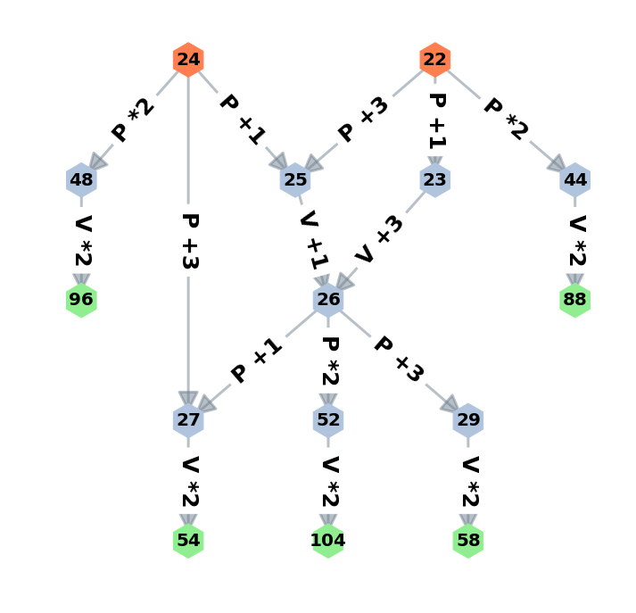

```python
plt.figure(figsize=(12,12))
GG = nx.DiGraph()

GG.add_edges_from([('22','23'),('22','25'),('22','44')])
GG.add_edges_from([('24','25'),('24','27'),('24','48')])
GG.add_edges_from([('23', '26'),('25','26')])
GG.add_edges_from([('26', '27'),('26','29'),('26','52')])
GG.add_edges_from([('44','88'),('27','54'),('48','96')])
GG.add_edges_from([('29', '58'),('52','104')])

pos = graphviz_layout(GG, prog='dot')

edge_labels={('22','23'):'P +1',('22','25'):'P +3',('22','44'):'P *2',
             ('24','25'):'P +1',('24','27'):'P +3',('24','48'):'P *2',
             ('23','26'):'V +3', ('25','26'):'V +1',
             ('26','27'):'P +1',('26','29'):'P +3',('26','52'):'P *2',
             ('44','88'):'V *2', ('27','54'):'V *2', ('48','96'):'V *2',
             ('29','58'):'V *2', ('52','104'):'V *2'}

node_colors=['coral','lightsteelblue','lightsteelblue','lightsteelblue','coral','lightsteelblue',
             'lightsteelblue','lightsteelblue','lightsteelblue','lightsteelblue','lightgreen',
             'lightgreen','lightgreen','lightgreen', 'lightgreen']

nx.draw_networkx_edges(GG, pos, width=3, alpha=0.5, edge_color='slategray',
                       arrowsize=50, arrowstyle='-|>')
nx.draw_networkx_nodes(GG, pos, node_size=1500, node_shape='h', node_color=node_colors)

nx.draw_networkx_edge_labels(GG, pos, edge_labels, font_size=25, font_weight='bold')
nx.draw_networkx_labels(GG, pos, font_size=20, font_weight='bold')

plt.axis('off')
plt.show()
```

#### Решение 27 / Solution 27

Отрезки удовлетворяют всем условиям задания, если координаты их начальных и конечных точек соответствуют требованиям:

- ни одна из координат не равна нулю;
- начало и конец отрезка лежат в 1 и 2 (2 и 1), 2 и 3 (3 и 2), 3 и 4 (4 и 3), 4 и 1 (1 и 4) координатных четвертях.

The segments satisfy all the conditions of the task if the coordinates of their initial and end points correspond to the requirements:

- none of the coordinates is equal to zero;
- the beginning and the end of the segment lie in the 1 and 2 (2 and 1), 2 and 3 (3 and 2), 3 and 4 (4 and 3), 4 and 1 (1 and 4) coordinate quarters.

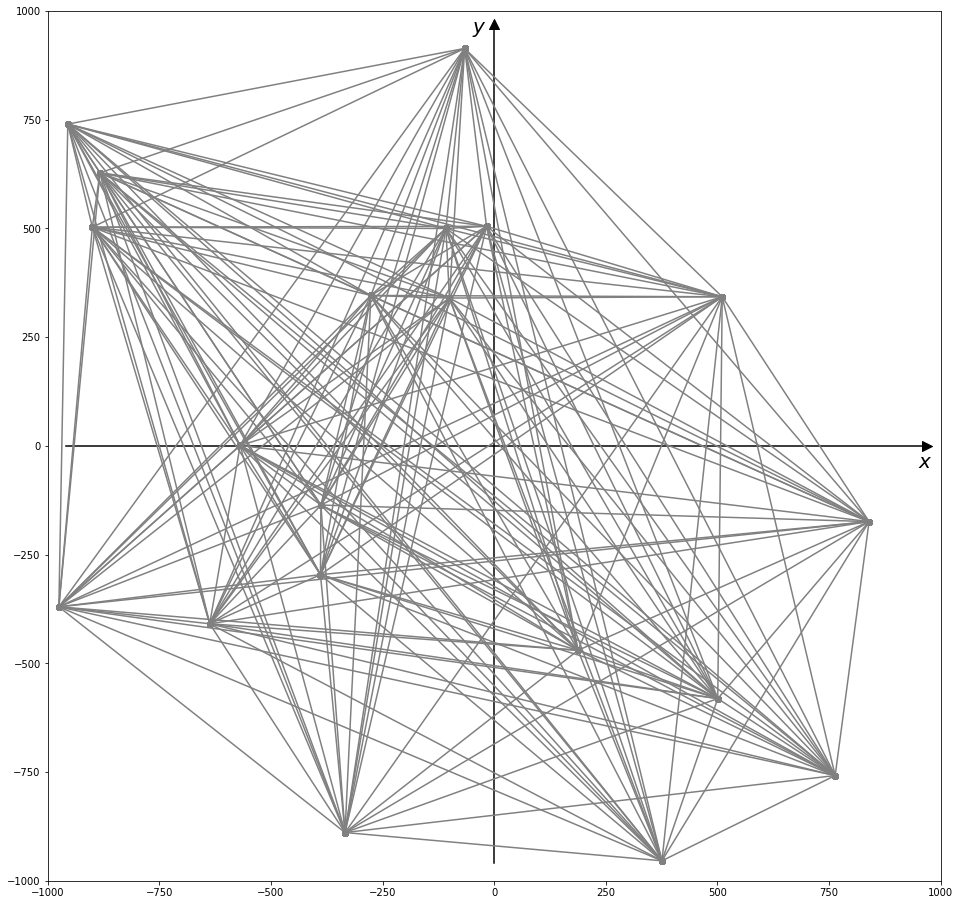

```python
# Для тестирования случайным образом генерируется массив пар целых чисел
A = numpy.random.randint(-1000, 1000, (20, 2))
plt.figure(figsize=(16,16))
plt.axhline(0,0.02,0.98,c='black')
plt.axvline(0,0.02,0.98,c='black')
plt.xlim(-1000,1000)
plt.ylim(-1000,1000)
plt.text(950,-50,r'$x$', fontsize=20)
plt.text(-50,950,r'$y$', fontsize=20)
plt.scatter(0,970, marker='^', s=100, c='black')
plt.scatter(970,0, marker='>', s=100, c='black')

for i in range(20):
    for j in range(i+1,20):
        plt.plot([A[i][0],A[j][0]],[A[i][1],A[j][1]] ,'-o',c='gray')
```

```python
line = 45*'-='
print(line,'\n')
N = int(input('Количество точек множества: \n'))
print(line,'\n')
print('Координаты точек:')
quarter1, quarter2, quarter3, quarter4= 0, 0, 0, 0
for i in range(N):
    xy = input(" ").split()
    x,y = int(xy[0]),int(xy[1])
    if x > 0 and y > 0:
        quarter1+=1
    elif x < 0 and y > 0:
        quarter2+=1
    elif x < 0 and y < 0:
        quarter3+=1
    elif x > 0 and y < 0:
        quarter4+=1

print(line,'\nКоличество удовлетворяющих требованиям отрезков:\n')
print(quarter1*quarter2+quarter2*quarter3+quarter3*quarter4+quarter4*quarter1)
```

```
-=-=-=-=-=-=-=-=-=-=-=-=-=-=-=-=-=-=-=-=-=-=-=-=-=-=-=-=-=-=-=-=-=-=-=-=-=-=-=-=-=-=-=-=-=

Количество точек множества:
10
-=-=-=-=-=-=-=-=-=-=-=-=-=-=-=-=-=-=-=-=-=-=-=-=-=-=-=-=-=-=-=-=-=-=-=-=-=-=-=-=-=-=-=-=-=

Координаты точек:
 1 1
 2 2
 -1 2
 -2 1
 -3 -4
 -4 -3
 5 -1
 2 -4
 4 5
 5 4
-=-=-=-=-=-=-=-=-=-=-=-=-=-=-=-=-=-=-=-=-=-=-=-=-=-=-=-=-=-=-=-=-=-=-=-=-=-=-=-=-=-=-=-=-=
Количество удовлетворяющих требованиям отрезков:

24
```

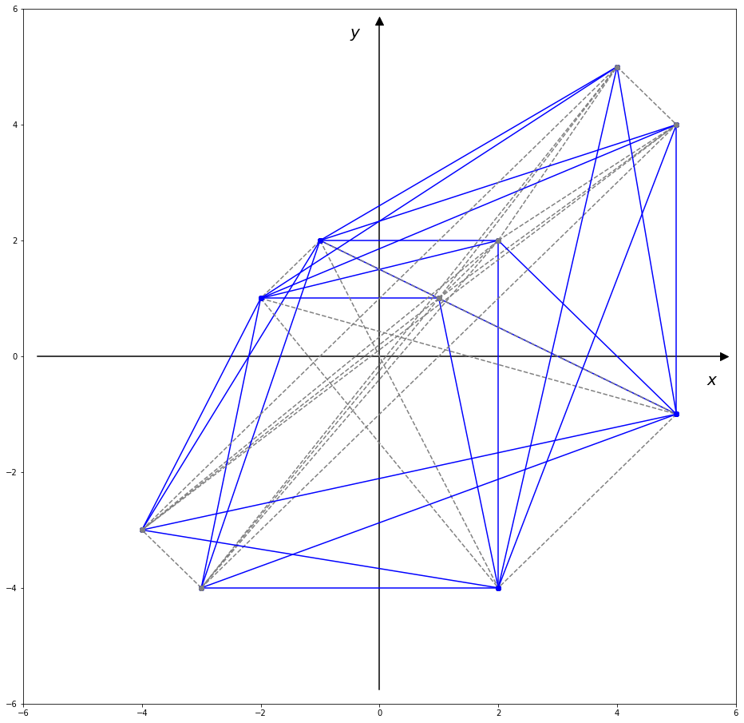

```python
A = [[1,1],[2,2],[-1,2],[-2,1],[-3,-4],[-4,-3],[5,-1],[2,-4],[4,5],[5,4]]
plt.figure(figsize=(16,16))
plt.axhline(0,0.02,0.98,c='black')
plt.axvline(0,0.02,0.98,c='black')
plt.xlim(-6,6)
plt.ylim(-6,6)
plt.text(5.5,-0.5,r'$x$', fontsize=20)
plt.text(-0.5,5.5,r'$y$', fontsize=20)
plt.scatter(0,5.8, marker='^', s=100, c='black')
plt.scatter(5.8,0, marker='>', s=100, c='black')

for i in range(10):
    for j in range(i+1,10):
        condition = (A[i][0]>0 and A[j][0]<0 and A[i][1]>0 and A[j][1]>0) or\
        (A[i][0]<0 and A[j][0]>0 and A[i][1]>0 and A[j][1]>0) or\
        (A[i][0]>0 and A[j][0]<0 and A[i][1]<0 and A[j][1]<0) or\
        (A[i][0]<0 and A[j][0]>0 and A[i][1]<0 and A[j][1]<0) or\
        (A[i][0]>0 and A[j][0]>0 and A[i][1]<0 and A[j][1]>0) or\
        (A[i][0]>0 and A[j][0]>0 and A[i][1]>0 and A[j][1]<0) or\
        (A[i][0]<0 and A[j][0]<0 and A[i][1]<0 and A[j][1]>0) or\
        (A[i][0]<0 and A[j][0]<0 and A[i][1]>0 and A[j][1]<0)

        if condition:
            color='blue'
            ls='-'
        else:
            color='gray'
            ls='--'

        plt.plot([A[i][0],A[j][0]],[A[i][1],A[j][1]] ,'-o',c=color,ls=ls)
```

#### Ответ 27 / Answer 27

Координаты начальных и конечных точек не должны быть равны нулю и лежать в (1;2)∨(2;1),(2;3)∨(3;2),(3;4)∨(4;3),(4;1)∨(1;4) координатных четвертях.

The coordinates of the initial and final points must not be equal to zero and lie in the (1; 2) ∨ (2; 1), (2; 3) ∨ (3; 2), (3; 4) ∨ (4; 3), ( 4; 1) ∨ (1; 4) coordinate quarters.

```bash
line = 45*'-='
print(line,'\n')
N = int(input('Количество точек множества: \n'))
print(line,'\n')
print('Координаты точек:')
quarter1, quarter2, quarter3, quarter4 = 0, 0, 0, 0
for i in range(N):
    xy = input(" ").split()
    x,y = int(xy[0]),int(xy[1])
    if x > 0 and y > 0:
        quarter1+=1
    elif x < 0 and y > 0:
        quarter2+=1
    elif x < 0 and y < 0:
        quarter3+=1
    elif x > 0 and y < 0:
        quarter4+=1

print(line,'\nКоличество удовлетворяющих требованиям отрезков:\n')
print(quarter1 * quarter2 + quarter2 * quarter3 + quarter3 * quarter4 + quarter4 * quarter1)
```

```python
answer_dictionary[27]=\
'''
line = 45*'-='
print(line,'\n')
N = int(input('Количество точек множества: \n'))
print(line,'\n')
print('Координаты точек:')
quarter1, quarter2, quarter3, quarter4 = 0, 0, 0, 0
for i in range(N):
    xy = input(" ").split()
    x,y = int(xy[0]),int(xy[1])
    if x > 0 and y > 0:
        quarter1+=1
    elif x < 0 and y > 0:
        quarter2+=1
    elif x < 0 and y < 0:
        quarter3+=1
    elif x > 0 and y < 0:
        quarter4+=1

print(line,'\nКоличество удовлетворяющих требованиям отрезков:\n')
print(quarter1 * quarter2 + quarter2 * quarter3 + quarter3 * quarter4 + quarter4 * quarter1)
'''
```

## Ответы / Answers

| 1 | 2 | 3 | 4 | 5 | 6 | 7 | 8 | 9 | 10 | 11 | 12 |
| --- | --- | --- | --- | --- | --- | --- | --- | --- | --- | --- | --- |
| 140 | $yxz$ | 22 | 2300 | 18 | 9878 | 80 | 33 | 30 | 320 | 38 | 192 |

| 13 | 14 | 15 | 16 | 17 | 18 | 19 | 20 | 21 | 22 | 23 |
| --- | --- | --- | --- | --- | --- | --- | --- | --- | --- | --- |
| 5 | 572 | 84 | 6 | 297 | 44 | 4 | 982 | 9 | 39 | 28 |

24

$1. 7;$  
$ 2. input = 4 \to output = 4, input = 12 \to output = 4;$  
$3. k = 2 \to k = 1, k = k + 1 \to k = k * 2$

25

```bash
N = 2016
a = []
m,s,p = 0,0,0
for i in range(N):
    a.append(int(input()))
    if a[i] > m:
        m = a[i]
    if a[i] % 2 == 0:
        s = s + a[i]
    else:
        p = p + a[i]
if m % 2 == 0:
    print('\n' + str(s))
else:
    print('\n' + str(p))
```

26

Задание 1.

$a. 27≤S≤53 → 54≤2*S≤106.$

$b. S=26. \; 26\to27(P+1),26\to29(P+3),26\to52(P*2); \; 27\to54(V*2),29\to58(V*2),52\to104(V*2).$

Задание 2.

$S=13, S=23, S=25.$

$13\to26(P*2),23\to26(P+3),25\to26(P+1)$

$26\to27(V+1),26\to29(V+3),26\to52(V*2)$

$27\to54(P*2),29\to58(P*2),52\to104(P*2)$

Задание 3.

$S=22, S=24.$

$22\to23(P+1),22\to25(P+3),22\to44(P*2) ∨ 24\to25(P+1),24\to27(P+3),24\to48(P*2)$

$23\to26(V+3),25\to26(V+1),44\to88(V*2),27\to54(V*2),48\to96(V*2)$

$26\to27(P+1),26\to29(P+3),26\to52(P*2)$

$27\to54(V*2),29\to58(V*2),52\to104(V*2)$

27

Координаты начальных и конечных точек не должны быть равны нулю и лежать в (1;2)∨(2;1),(2;3)∨(3;2),(3;4)∨(4;3),(4;1)∨(1;4) координатных четвертях.

```bash
line = 45*'-='
print(line,'\n')
N = int(input('Количество точек множества: \n'))
print(line,'\n')
print('Координаты точек:')
quarter1, quarter2, quarter3, quarter4 = 0, 0, 0, 0
for i in range(N):
    xy = input(" ").split()
    x,y = int(xy[0]),int(xy[1])
    if x > 0 and y > 0:
        quarter1+=1
    elif x < 0 and y > 0:
        quarter2+=1
    elif x < 0 and y < 0:
        quarter3+=1
    elif x > 0 and y < 0:
        quarter4+=1

print(line,'\nКоличество удовлетворяющих требованиям отрезков:\n')
print(quarter1 * quarter2 + quarter2 * quarter3 + quarter3 * quarter4 + quarter4 * quarter1)
```